# Differential Expression Analysis

This notebook shows the differential expression analysis for the experiment c5a_vs_control.

There are different graphs that represent an exploratory analysis of the data, the quality of the results and the list of genes that have a relevant difference in expression bettewn two groups of samples.

### Load libraries

- **edger:** Library to normalize RNA-seq expression data [1].
- **noiseq:** Using noiseq exploratory plots to evaluate the quality of the results [2].
- **biomart:** Interface to biomart databases [3]

```r
library(gplots)
library(edgeR)
library(NOISeq)
library(biomaRt)

# Parameters
expName = params$expName
cpmLimit = params$cpm
pValueLimit = params$pvalue
```

### Load Experimental data

Loading count data from output of *featurecounts* tool.

```r
sampleinfo <- read.csv(paste("setup/", expName, ".tsv", sep=""), sep = " ")
seqdata <- read.delim(paste("count/", expName, "_count.tsv", sep=""), sep = "\t", stringsAsFactors = FALSE, header=TRUE, skip=1)

counts <- seqdata[,(7:ncol(seqdata))]
rownames(counts) <- seqdata[,1]
colnames(counts) <- sampleinfo[,3]

groups <- sampleinfo[,4]

group0numSamples <- sum(sampleinfo[,5]==0)
group1numSamples <- sum(sampleinfo[,5]==1)
sampleinfo
```

```
##                    FastaFile                   BamFile SampleName
## 1     reads/C5a1_mappable.fq     bam/C5a1_mappable.bam       C5a1
## 2     reads/C5a2_mappable.fq     bam/C5a2_mappable.bam       C5a2
## 3     reads/C5a3_mappable.fq     bam/C5a3_mappable.bam       C5a3
## 4 reads/Control1_mappable.fq bam/Control1_mappable.bam   Control1
## 5 reads/Control2_mappable.fq bam/Control2_mappable.bam   Control2
## 6 reads/Control3_mappable.fq bam/Control3_mappable.bam   Control3
##   SampleGroup Group
## 1         C5a     0
## 2         C5a     0
## 3         C5a     0
## 4     Control     1
## 5     Control     1
## 6     Control     1
```

### TMM Normalization (Edger)

```r
# Set up the groups based on the experimental setup.
cond_1 = rep("cond1", group0numSamples)
cond_2 = rep("cond2", group1numSamples)

# Create the groups.
group=c(cond_1, cond_2)

dge <- DGEList(counts=counts, group=group)
dge <- estimateCommonDisp(dge)
dge <- estimateGLMTrendedDisp(dge)
dge <- estimateTagwiseDisp(dge)


# Perform pairwise comparison.
etx <- exactTest(dge)
etp <- topTags(etx, n=100000, sort.by="p.value")

# Generate the output.
edgerCountsFile <- paste("count/", expName, "_count_edger.tsv", sep="")
edgerCounts <- etp$table
write.table(edgerCounts, file=edgerCountsFile, sep="\t", row.name=TRUE, quote=FALSE)

# Get normalized counts and write to a file
scale = dge$samples$lib.size*dge$samples$norm.factors
nc = round(t(t(counts)/scale)*mean(scale))

# Turn it into a dataframe to have proper column names.
dt = data.frame("id"=rownames(nc),nc)

# Save into the normalize data matrix.
normCountsFile <- paste("count/", expName, "_count_norm.tsv", sep="")
normCounts <- dt
write.table(dt, file=normCountsFile, sep="\t", row.name=FALSE, col.names=TRUE, quote=FALSE)
```

# Exploration Analysis

Build the data structure for all the NOISEQ graphs.

```r
vectorbase_gene <- new("Mart", biomart = "vb_gene_mart_1902", vschema = "vb_mart_1902", host = "https://biomart.vectorbase.org/biomart/martservice")
aaegGenes<-useDataset("alvpagwg_eg_gene", vectorbase_gene)

sample_biotype <- getBM(attributes = c("ensembl_gene_id", "gene_biotype"), mart = aaegGenes)
sample_gc_content <- getBM(attributes = c("ensembl_gene_id", "percentage_gene_gc_content"), mart = aaegGenes)
sample_length <- seqdata[,c(1,6)]
sample_chrm_pos <- getBM(attributes = c("ensembl_gene_id", "chromosome_name", "start_position", "end_position"), mart = aaegGenes)
sample_chrm <- sample_chrm_pos[, c(2,3,4)]
rownames(sample_chrm) <- sample_chrm_pos[,1]
sample_factors <- sampleinfo[,c(3,4,5)]
sample_count <- normCounts[, 2:ncol(normCounts)]

noiseq_data <- readData(data=sample_count,length=sample_length, biotype=sample_biotype, gc=sample_gc_content, chromosome=sample_chrm, factors=sample_factors)
```

### Countsbio plots

```r
# Build countbio data
countsbio_data = dat(noiseq_data, factor = NULL, type = "countsbio")
```

```
## [1] "Warning: 7150 features with 0 counts in all samples are to be removed for this analysis."
## [1] "Count distributions are to be computed for:"
## [1] "C5a1"     "C5a2"     "C5a3"     "Control1" "Control2" "Control3"
```

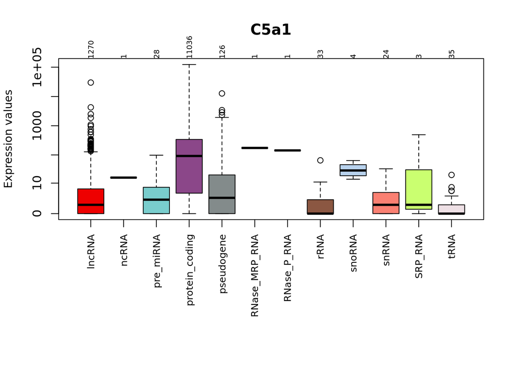

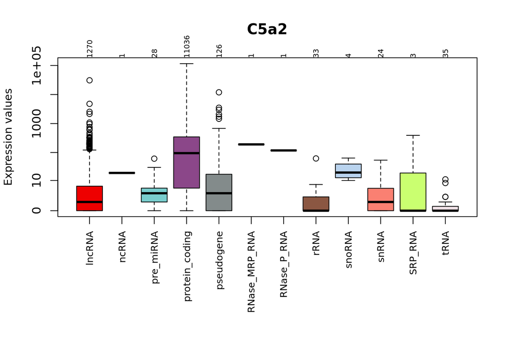

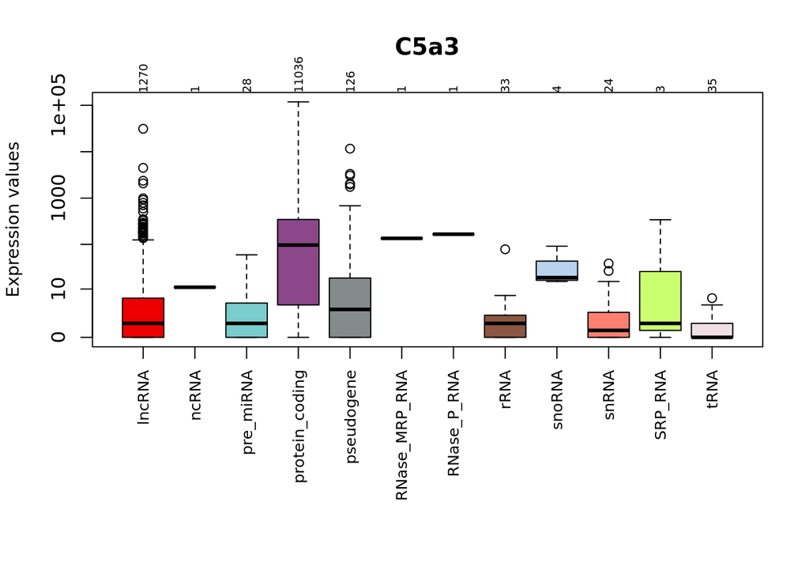

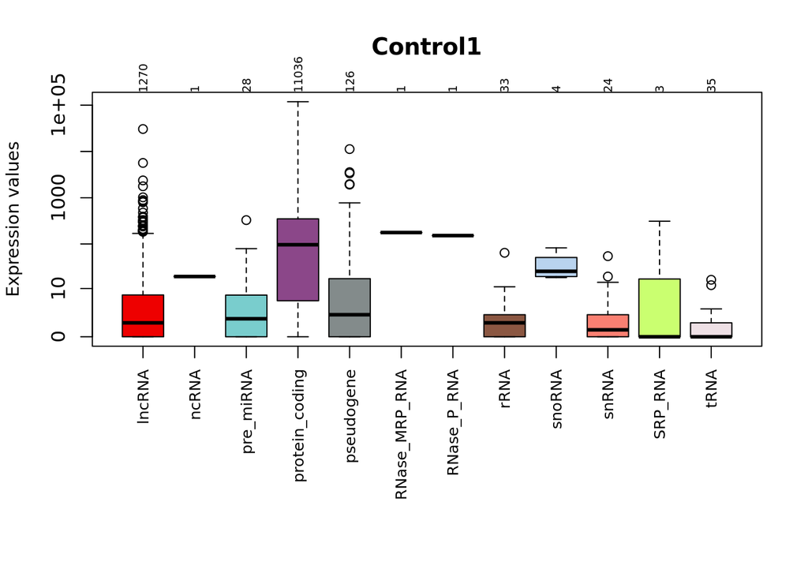

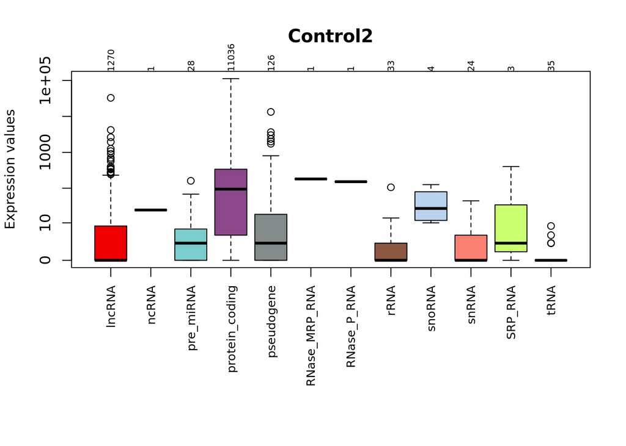

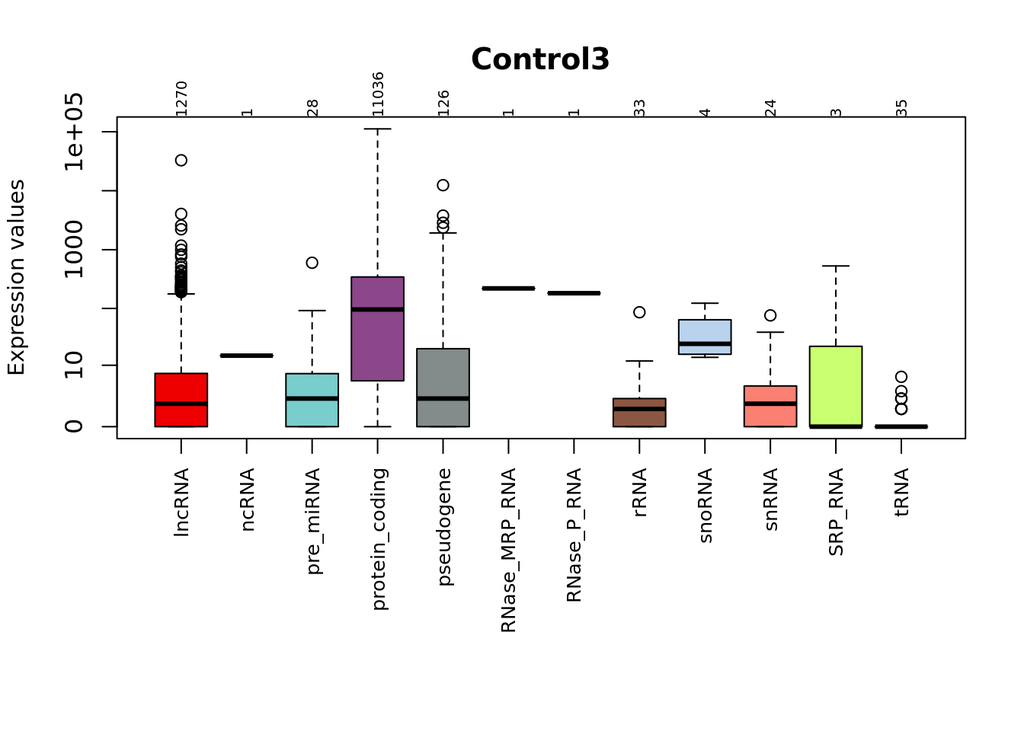

```r
# Count data samples
for( i in 1:nrow(sampleinfo)){
  explo.plot(countsbio_data, toplot = 1, samples = i, plottype = "boxplot")
}
```

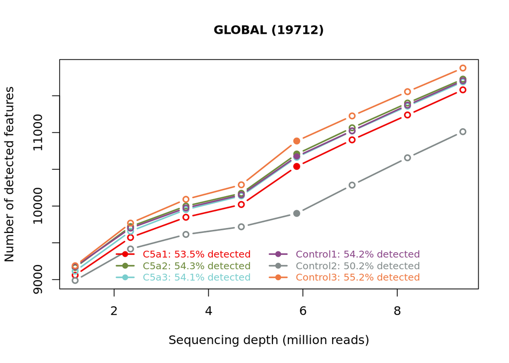

```r
# Saturation plot
saturation_data = dat(noiseq_data, k = 0, ndepth = 7, type = "saturation")
explo.plot(saturation_data, toplot = 1, samples = 1:nrow(sampleinfo), yleftlim = NULL, yrightlim = NULL)
```

### Biodetection plots

The gray bar corresponds to the percentage of each biotypein the genome, the stripped color bar is the proportion detected in oursample, and the solid color bar is the percentage of each biotype withinthe sample. The vertical green line separates the most abundant biotypes from the rest (in the right-hand side, corresponding to the right axis scale).

```r
# data
biodetection_data <- dat(noiseq_data, type = "biodetection")
```

```
## Biotypes detection is to be computed for:
## [1] "C5a1"     "C5a2"     "C5a3"     "Control1" "Control2" "Control3"
```

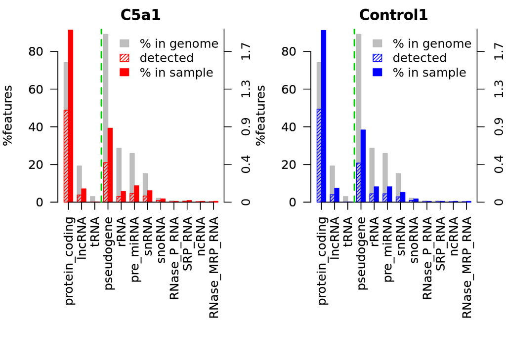

```r
par(mfrow = c(1, 2))
explo.plot(biodetection_data, samples = c(1, 1 + group0numSamples), plottype = "persample")
```

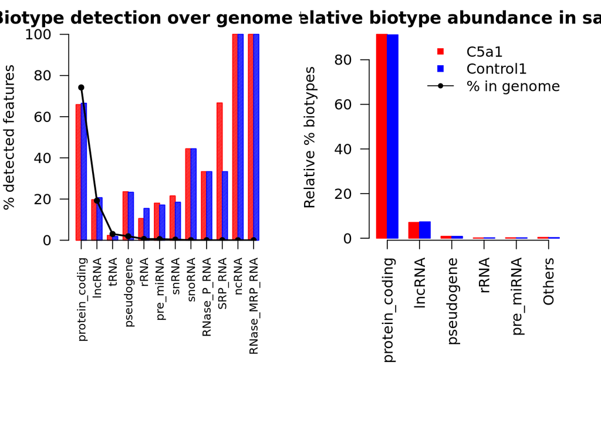

```
## [1] "Percentage of protein_coding biotype in each sample:"
##     C5a1 Control1
##  91.3961  91.1780
## [1] "Confidence interval at 95% for the difference of percentages: C5a1 - Control1"
## [1] -0.3437  0.7800
## [1] "The percentage of this biotype is NOT significantly different for these two samples (p-value = 0.4532 )."
```

```r
par(mfrow = c(1, 2))
explo.plot(biodetection_data, samples = c(1, 1 + group0numSamples), toplot = "protein_coding", plottype = "comparison")
```

### Sensitivity

The “Sensitivity plot” helps to decide the threshold to remove low-count features by indicating the proportion of such features that are presentin our data.

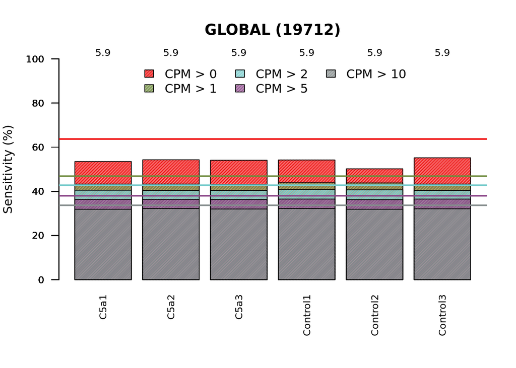

```r
explo.plot(countsbio_data, toplot = 1, samples = NULL, plottype = "barplot")
```

### Length Bias

The “lengthbias” plot describes the relationship between the feature length and the expression values.

```r
lengthbias_data = dat(noiseq_data, factor = "SampleGroup", type = "lengthbias")
```

```
## [1] "Warning: 7150 features with 0 counts in all samples are to be removed for this analysis."
## [1] "Length bias detection information is to be computed for:"
## [1] "C5a"     "Control"
## [1] "C5a"
##
## Call:
## lm(formula = datos[, i] ~ bx)
##
## Residuals:
##     Min      1Q  Median      3Q     Max
## -16.873  -8.477  -1.732   3.282  75.172
##
## Coefficients: (1 not defined because of singularities)
##             Estimate Std. Error t value Pr(>|t|)
## (Intercept)    61.20      16.59   3.688 0.000534 ***
## bx1           -50.44      20.54  -2.456 0.017363 *
## bx2           -10.21      19.92  -0.513 0.610421
## bx3           -43.31      20.69  -2.094 0.041084 *
## bx4            16.40      21.64   0.758 0.451973
## bx5           -25.86      26.84  -0.963 0.339740
## bx6            19.28      44.10   0.437 0.663689
## bx7          -292.63     679.09  -0.431 0.668277
## bx8          5906.07   18481.17   0.320 0.750549
## bx9               NA         NA      NA       NA
## ---
## Signif. codes:  0 '***' 0.001 '**' 0.01 '*' 0.05 '.' 0.1 ' ' 1
##
## Residual standard error: 16.59 on 53 degrees of freedom
## Multiple R-squared:  0.3202, Adjusted R-squared:  0.2176
## F-statistic: 3.121 on 8 and 53 DF,  p-value: 0.005794
##
## [1] "Control"
##
## Call:
## lm(formula = datos[, i] ~ bx)
##
## Residuals:
##     Min      1Q  Median      3Q     Max
## -17.182  -8.414  -1.676   3.545  77.187
##
## Coefficients: (1 not defined because of singularities)
##              Estimate Std. Error t value Pr(>|t|)
## (Intercept)    58.968     17.018   3.465  0.00106 **
## bx1           -47.213     21.060  -2.242  0.02918 *
## bx2            -6.966     20.429  -0.341  0.73447
## bx3           -41.316     21.215  -1.947  0.05678 .
## bx4            18.250     22.190   0.822  0.41450
## bx5           -24.617     27.526  -0.894  0.37520
## bx6            19.933     45.226   0.441  0.66120
## bx7          -291.588    696.430  -0.419  0.67714
## bx8          5934.401  18953.007   0.313  0.75542
## bx9                NA         NA      NA       NA
## ---
## Signif. codes:  0 '***' 0.001 '**' 0.01 '*' 0.05 '.' 0.1 ' ' 1
##
## Residual standard error: 17.02 on 53 degrees of freedom
## Multiple R-squared:  0.2858, Adjusted R-squared:  0.178
## F-statistic: 2.651 on 8 and 53 DF,  p-value: 0.01593
```

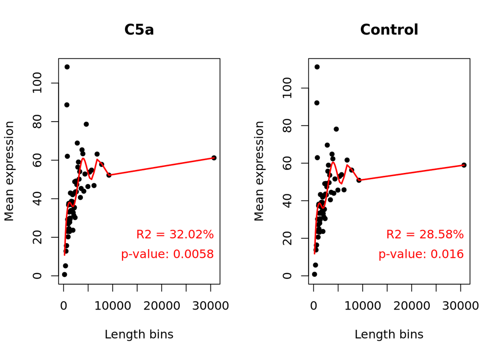

```r
explo.plot(lengthbias_data, samples = NULL, toplot = "global")
```

### GC Content Bias

The “GCbias” plot describes the relationship between the feature GC content and the expression values.

```r
gc_data = dat(noiseq_data, factor = "SampleGroup", type = "GCbias")
```

```
## [1] "Warning: 7150 features with 0 counts in all samples are to be removed for this analysis."
## [1] "GC content bias detection is to be computed for:"
## [1] "C5a"     "Control"
## [1] "C5a"
##
## Call:
## lm(formula = datos[, i] ~ bx)
##
## Residuals:
##      Min       1Q   Median       3Q      Max
## -14.4154  -3.4425  -0.0088   3.4363  17.8216
##
## Coefficients: (1 not defined because of singularities)
##             Estimate Std. Error t value Pr(>|t|)
## (Intercept)   16.777      6.952   2.413 0.019309 *
## bx1          -13.742      9.832  -1.398 0.168033
## bx2         3561.405   5609.223   0.635 0.528213
## bx3          -85.513     44.118  -1.938 0.057923 .
## bx4           25.668     10.970   2.340 0.023095 *
## bx5           41.650      9.046   4.604 2.63e-05 ***
## bx6           -7.252     10.191  -0.712 0.479870
## bx7           90.959     22.441   4.053 0.000166 ***
## bx8         -285.158    105.780  -2.696 0.009391 **
## bx9               NA         NA      NA       NA
## ---
## Signif. codes:  0 '***' 0.001 '**' 0.01 '*' 0.05 '.' 0.1 ' ' 1
##
## Residual standard error: 6.952 on 53 degrees of freedom
## Multiple R-squared:  0.6784, Adjusted R-squared:  0.6298
## F-statistic: 13.97 on 8 and 53 DF,  p-value: 1.116e-10
##
## [1] "Control"
##
## Call:
## lm(formula = datos[, i] ~ bx)
##
## Residuals:
##      Min       1Q   Median       3Q      Max
## -13.8209  -3.2609  -0.0444   3.0533  18.3270
##
## Coefficients: (1 not defined because of singularities)
##             Estimate Std. Error t value Pr(>|t|)
## (Intercept)   16.675      6.910   2.413 0.019304 *
## bx1          -13.426      9.772  -1.374 0.175268
## bx2         3300.643   5575.002   0.592 0.556339
## bx3          -80.937     43.849  -1.846 0.070506 .
## bx4           25.656     10.903   2.353 0.022362 *
## bx5           41.453      8.991   4.610 2.57e-05 ***
## bx6           -6.902     10.129  -0.681 0.498596
## bx7           91.025     22.304   4.081 0.000152 ***
## bx8         -288.042    105.135  -2.740 0.008359 **
## bx9               NA         NA      NA       NA
## ---
## Signif. codes:  0 '***' 0.001 '**' 0.01 '*' 0.05 '.' 0.1 ' ' 1
##
## Residual standard error: 6.91 on 53 degrees of freedom
## Multiple R-squared:  0.6745, Adjusted R-squared:  0.6254
## F-statistic: 13.73 on 8 and 53 DF,  p-value: 1.506e-10
```

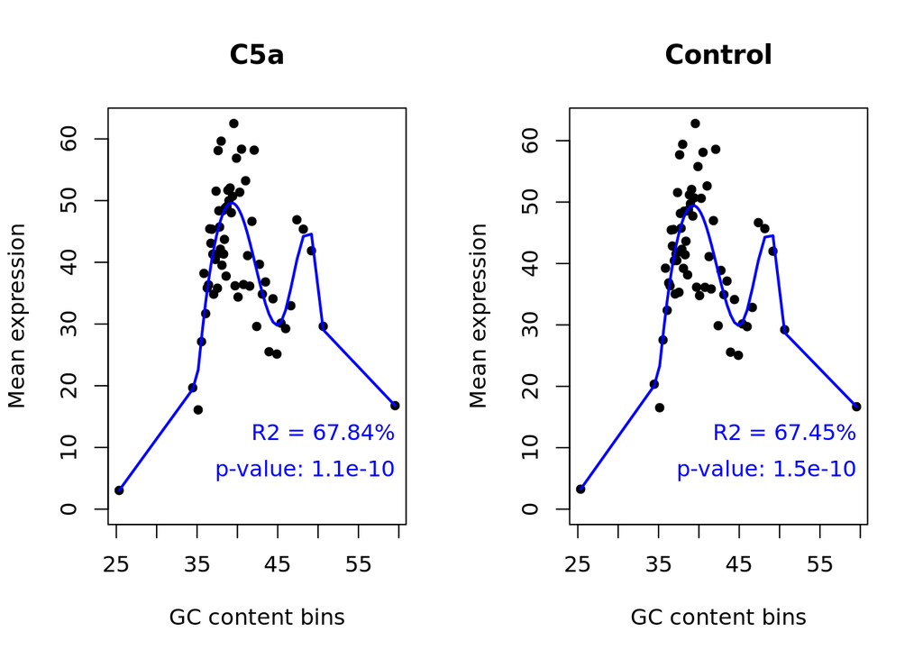

```r
explo.plot(gc_data, samples = NULL, toplot = "global")
```

### Count Stats

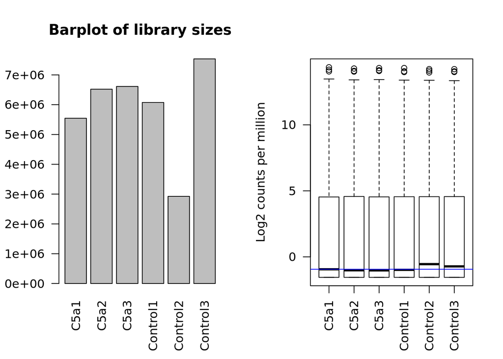

```r
par(mfrow = c(1, 2))
# Check library Sizes
barplot(dge$samples$lib.size, names=colnames(dge), las=2, main="Barplot of library sizes")
abline(h=20e6, lty=2)

# If a sample is really far above or below the blue horizontal line we may need to investigate that sample further
logcounts <- cpm(dge,log=TRUE)
boxplot(logcounts, xlab="", ylab="Log2 counts per million",las=2)
abline(h=median(logcounts), col="blue", main="Boxplots of logCPMs (unnormalised)")
```

### Principal Component Analysis

Visualize if the experimental samples are clustered according to the experimental design or if there is an unwanted source of noise in the data that hampers this clustering is the Principal Component Analysis.

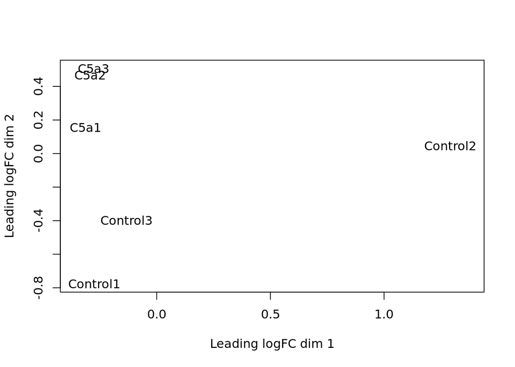

```r
# Principle components analysis
plotMDS(dge)
```

```r
cd_data = dat(noiseq_data, type = "cd", norm = FALSE, refColumn = 1)
```

```
## [1] "Warning: 7150 features with 0 counts in all samples are to be removed for this analysis."
## [1] "Reference sample is: C5a1"
## [1] "Confidence intervals for median of M:"
##          0.5%                    99.5%                   Diagnostic Test
## C5a2     "-0.000181637422111274" "0.00271604696794364"   "PASSED"
## C5a3     "-0.00012854955295765"  "-0.00012854955295765"  "FAILED"
## Control1 "-0.000127812207687127" "-0.000127812207687127" "FAILED"
## Control2 "2.7038648838419e-05"   "2.7038648838419e-05"   "FAILED"
## Control3 "-0.00012240499752073"  "-0.00012240499752073"  "FAILED"
## [1] "Diagnostic test: FAILED. Normalization is required to correct this bias."
```

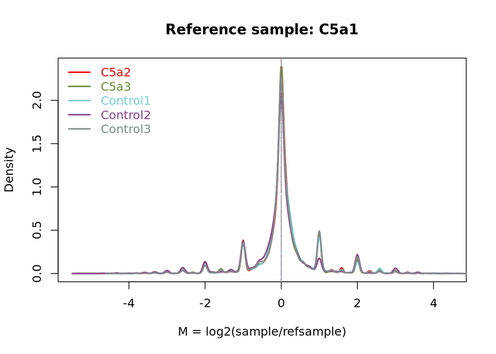

```r
explo.plot(cd_data)
```

# Differential Expression

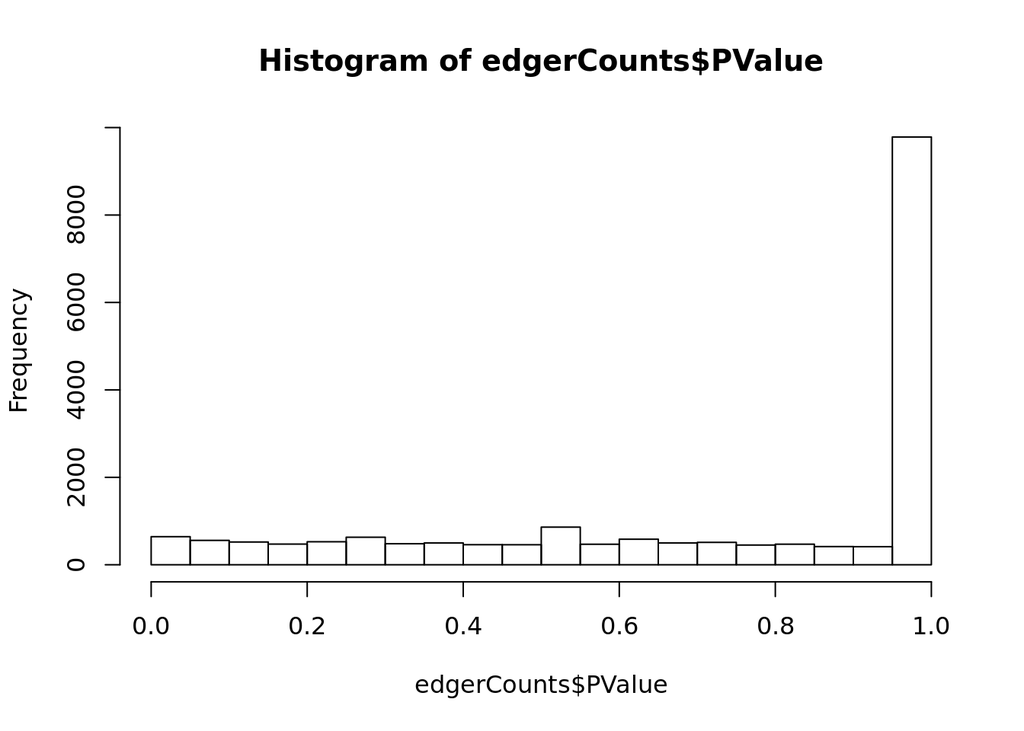

```r
# Histogram of PValue
hist(edgerCounts$PValue)
```

```r
# Summary of Expression Analysis
design <- model.matrix(~ groups)
fit <- glmFit(dge, design)
lrt.BvsL <- glmLRT(fit, coef=2)
results <- as.data.frame(topTags(lrt.BvsL,n = Inf))
summary(de <- decideTestsDGE(lrt.BvsL))
```

```
##        groupsControl
## Down               0
## NotSig         19708
## Up                 4
```

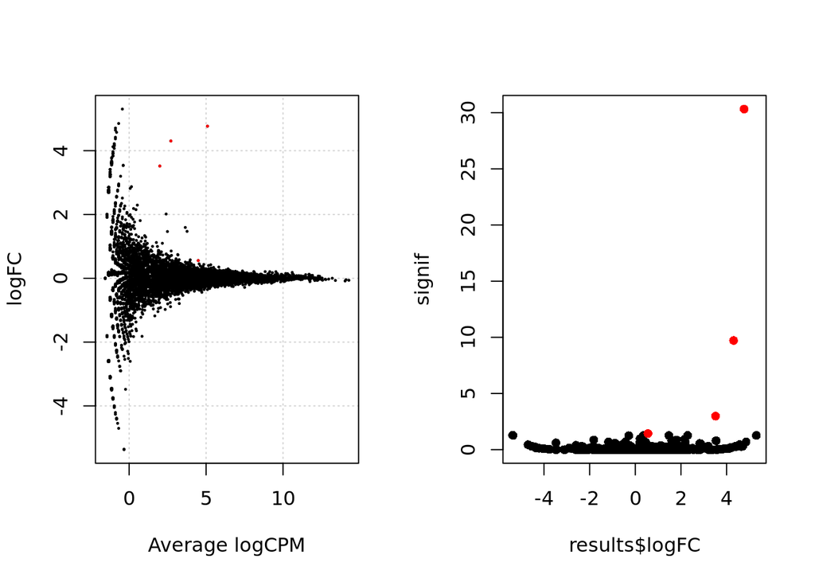

```r
par(mfrow = c(1, 2))
# Log-fold change against log-counts per million with DE genes highlighted
detags <- rownames(dge)[as.logical(de)]
plotSmear(lrt.BvsL, de.tags=detags)

# Volcano plot
signif <- -log10(results$FDR)
plot(results$logFC,signif,pch=16)
points(results[detags,"logFC"],-log10(results[detags,"FDR"]),pch=16,col="red")
```

## Filtering

Filteing the results using a the conditions of pvalue < 0.05 and cpm > 0.5

```r
cpmValues <- cpm(sample_count)
threshCPM <- cpmValues > cpmLimit
keepCPM <- rowSums(threshCPM) >= min(group0numSamples, group1numSamples)

# P-Value
keepPValue <- edgerCounts[,3] < pValueLimit

sample_count_filtered <- sample_count[keepCPM & keepPValue,]

sample_count_filtered_sub <- sample_count_filtered[1:20,]
sample_count_filtered_sub
```

```
##            C5a1 C5a2 C5a3 Control1 Control2 Control3
## AAEL026536    7    2    0        7        4        5
## AAEL024089    3    5    4        4        2        5
## AAEL026215   65  110   89      107       88       71
## AAEL021190    1    2    5        3        0        5
## AAEL009339  128  115  130      132      104      104
## AAEL023380    7    6    6        8       10        5
## AAEL022169   14   26   24       24       24       19
## AAEL026780    5    4    3        2        0        3
## AAEL022013    5    8   10       10        2       10
## AAEL020524   74   75   94      100       94       71
## AAEL003192   50   50   58       57       52       62
## AAEL017258   11    5    4        3       14        3
## AAEL007077   21   16   36       23       14       26
## AAEL024775   38   65   47       56       48       45
## AAEL024516    7    7    9        6        6        5
## AAEL022981   15   10   11        4        6       14
## AAEL025400    2    9    3        4        8        3
## AAEL022167    6    6   10       10        4       11
## AAEL021447   21   23   30       24       22       22
## AAEL026175  310  334  359      359      299      332
```

```r
sample_filtered_info <- getBM(attributes = c("ensembl_gene_id", "chromosome_name", "gene_biotype", "description", "protein_id", "go_id"), filters = "ensembl_gene_id", values = rownames(sample_count_filtered),  mart = aaegGenes)

write.table(sample_filtered_info, file=paste("count/", expName, "_final.tsv", sep=""), sep="\t", col.names=TRUE, quote=FALSE)
```

66 genes left of 19712

### HeatMap

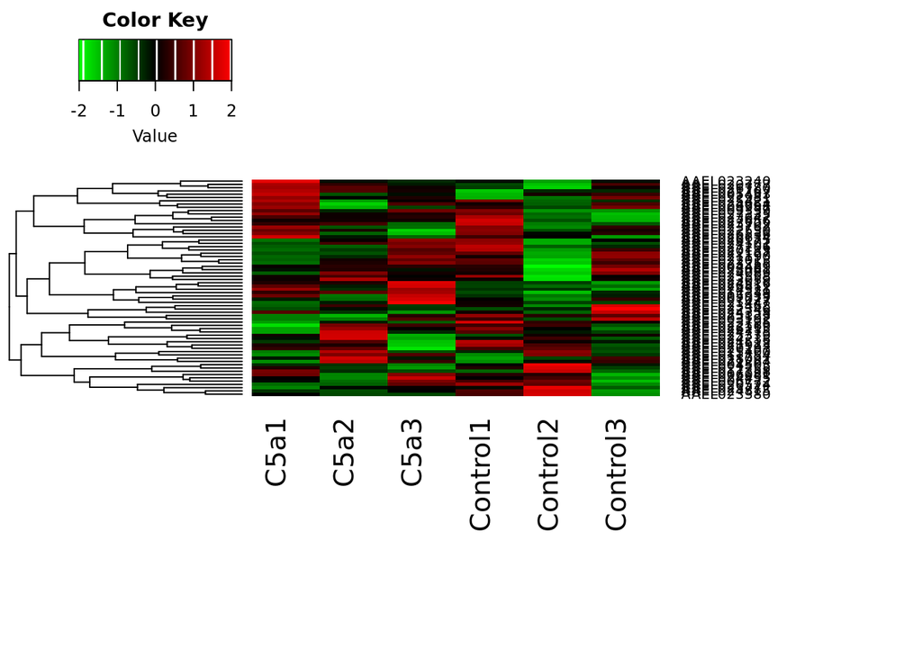

```r
# Read normalized counts

gene = rownames(sample_count_filtered)
vals = as.matrix(sample_count_filtered)

# Adds a little noise to each element
# To avoid the clusteing function failing on zero
# variance datalines.
vals = jitter(vals, factor = 1, amount=0.00001)


# Calculate zscore
score = NULL
for (i in 1:nrow(vals)) {
    row=vals[i,]
    zscore=(row-mean(row))/sd(row)
    score =rbind(score,zscore)
}

row.names(score) = gene
zscore=score

# Generate heatmap
mat = as.matrix(zscore)

colors = colorRampPalette(c("green","black","red"),space="rgb")(256)
heatmap.2(mat,col=colors,density.info="none",trace="none", Colv=FALSE, margins=c(12,12))
```

## References

1. Edger.https://bioconductor.org/packages/release/bioc/html/edgeR.html
2. Noiseq. https://bioconductor.org/packages/release/bioc/html/NOISeq.html
3. Biomart. https://bioconductor.org/packages/release/bioc/html/biomaRt.html